# Update to the R POPGRAPH library

As part of an ongoing research project, I was simulating some populatiuon graph structures and found an annoying feture in the current popgraph library when comparing disconnected graphs for distance congruence. Fixed it and updated the version to 1.5.3

Published

March 22, 2022

A population graph is a graph-theoretic representation of population genetic covariance, which can arrise from a host of micro and macro evolutionary processes (see [Dyer & Nason 2004](https://dyerlab.org/manuscripts/dyer-nason-2004/) for a more complete description) using the *Lophocereus schottii* topology depicted below.

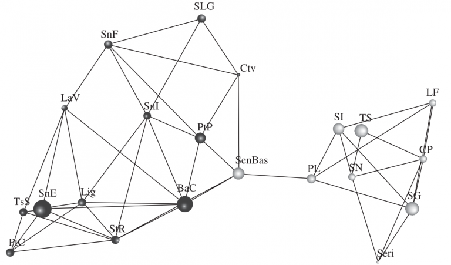

The first population graph based upon the spatial genetic structure of the sonoran desert cactus, *Lophocereus schottii*

For these analyses, I have written an R package named `popgraph` that does all the under-the-scenes kinds of stuff. One of the things I’m currently working on is extending this to use in genomic contexts. For this, I’ve been developing the tools for additional analyses, one of which is concerned with comparing large numbers of topologies. Well, today I found an annoying ‘feature’ in the library that would not give an answer with specific kinds of topological structure. I didn’t give the wrong answer, it just gave you a “I cannot give you an answer” kind of answer, which is annoying.

So I fixed it and updated the package ([github](https://github.com/dyerlab/popgraph)). If you are following along at home and need to do congruent tests, version 1.5.3 and later will be less annoying (and more information rich). Enjoy!